# CibNav : construction d’un modèle transparent

## Exploration du modèle via des jeux de données simulés

```r
yrep <- posterior_predict(mod_nb)
```

Nous entraînons le modèle puis générons des jeux de données, simulés pour les diagnostics.

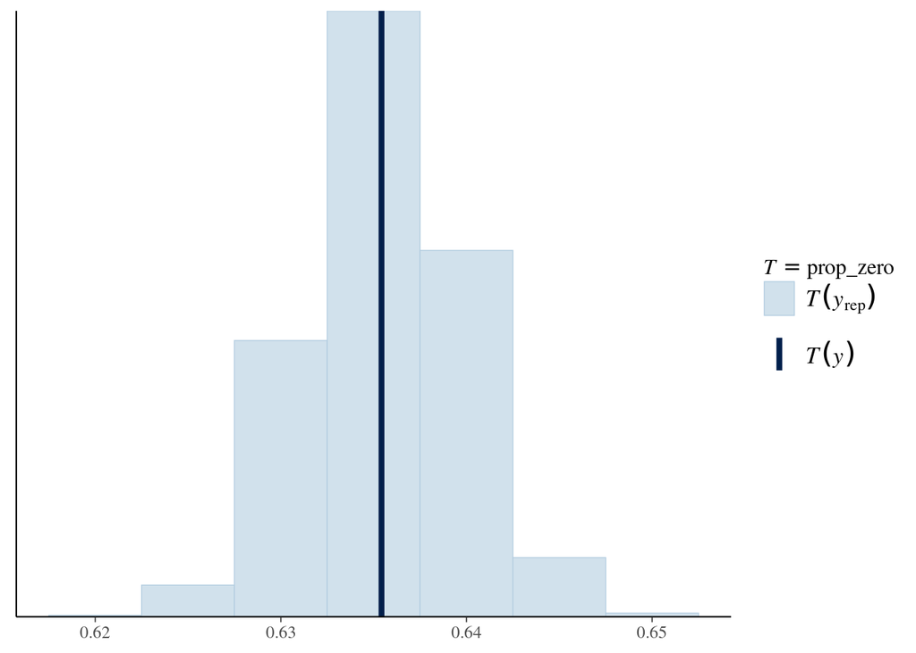

```r
prop_zero <- function(y) mean(y == 0)
pp_check(mod_nb, plotfun = "stat", stat = "prop_zero", binwidth = .005)
```

Contrairement à la distribution poisson, la distribution négative binomiale arrive à très bien capturer le nombre d’observations sans prescription majeure.

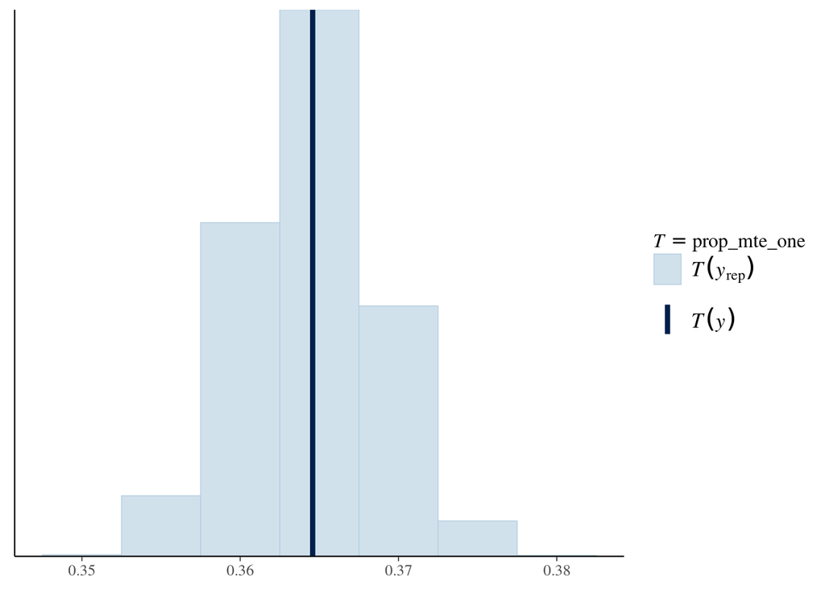

```r
prop_mte_one <- function(y) mean(y >= 1)
pp_check(mod_nb, plotfun = "stat", stat = "prop_mte_one", binwidth = .005)
```

La distribution capture également de manière convaincante le nombre d’observations pour lesquelles il y au moins une prescription majeure.

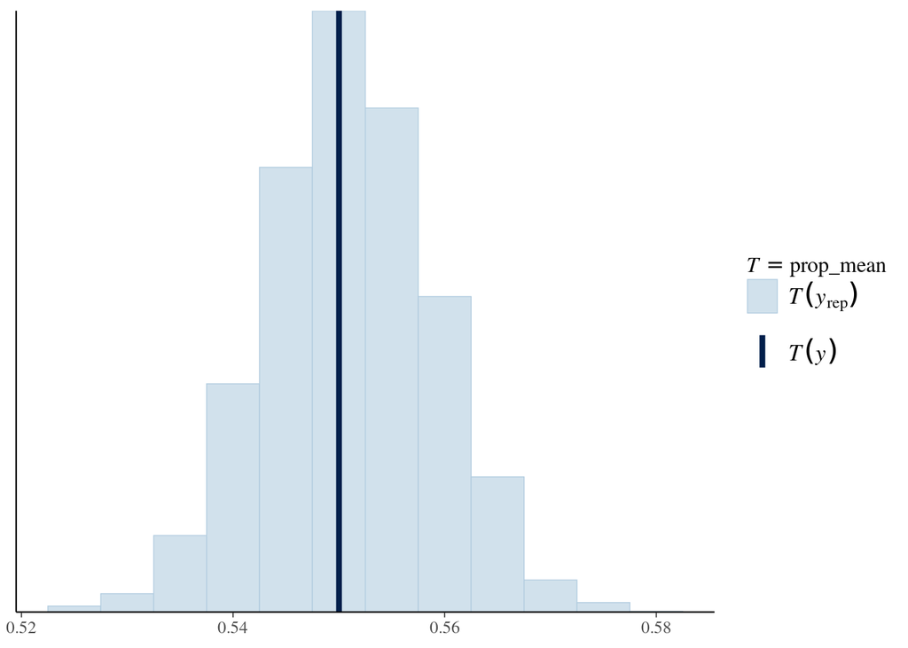

```r
prop_mean <- function(y) mean(y)
pp_check(mod_nb, plotfun = "stat", stat = "prop_mean", binwidth = .005)
```

La distribution simulée capture bien le nombre moyen de prescriptions majeures.

```r
op <- mod_nb$data %>%
  select(
    "nombre_prescriptions_majeurs_hist",
    "nombre_prescriptions_hist",
    "age",
    "log_longueur_hors_tout",
    "longueur_e12",
    "longueur_mt12",
    "log_puissance_administrative",
    "type_moteur",
    "situation_flotteur",
    "genre_navigation",
    "idc_gin_categ_navigation"
  )
d <- mod_nb$data[complete.cases(op),]
```

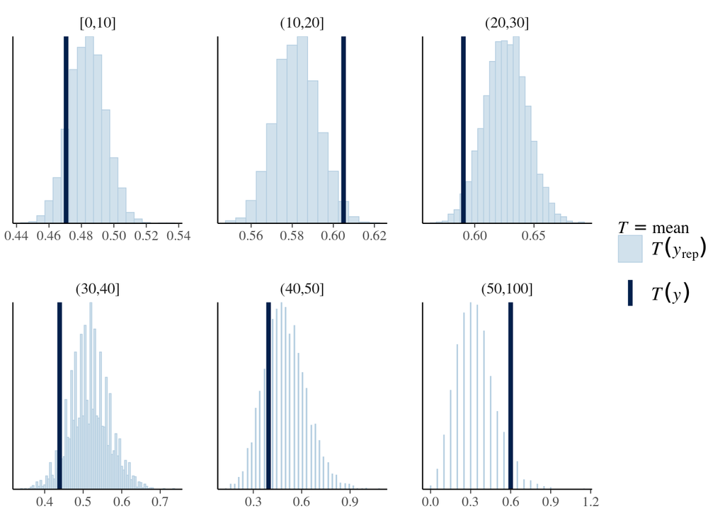

```r
age <- d$age * sd(df$age)

ppc_stat_grouped(
  y = mod_nb$y,
  yrep = yrep,
  group = cut(age, c(0,10,20,30,40,50,100), include.lowest = TRUE),
  stat = "mean",
  binwidth = .005
)
```

Le modèle capture modérément bien la dynamique avec l’âge. Le modèle sous-estime le nombre de pm pour la catégorie [10, 20] et surestime pour la catégorie [20, 30].

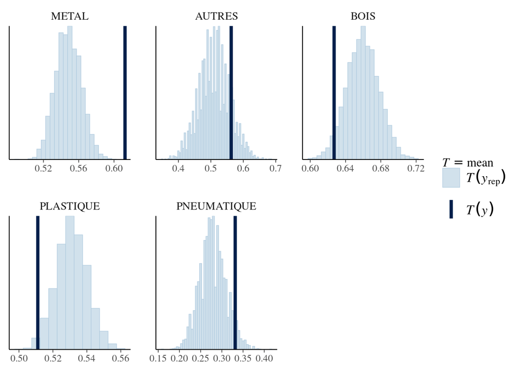

```r
materiau_coque <- d$materiau_coque

notNA <- !is.na(materiau_coque)

ppc_stat_grouped(
  y = mod_nb$y[notNA],
  yrep = yrep[, notNA],
  group = materiau_coque[notNA],
  stat = "mean",
  binwidth = .005
)
```

Le modèle sous-estime le nombre de pm pour les coques metal et surestime pour les coques bois et plastique. Le modèle gagnerait à bénéficier de cette information.

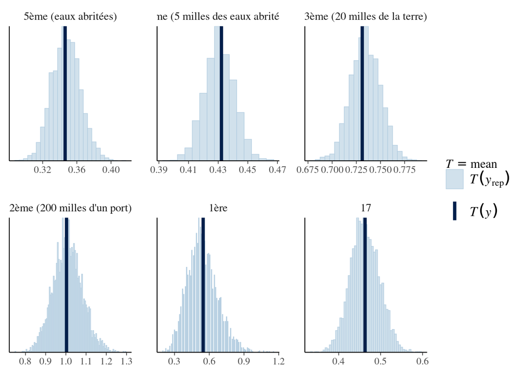

```r
categ <- d$idc_gin_categ_navigation

ppc_stat_grouped(
  y = mod_nb$y,
  yrep = yrep,
  group = categ,
  stat = "mean",
  binwidth = .005
)
```

Sans surprise, la dynamique liée à la catégorie de navigation est bien représentée par le modèle.

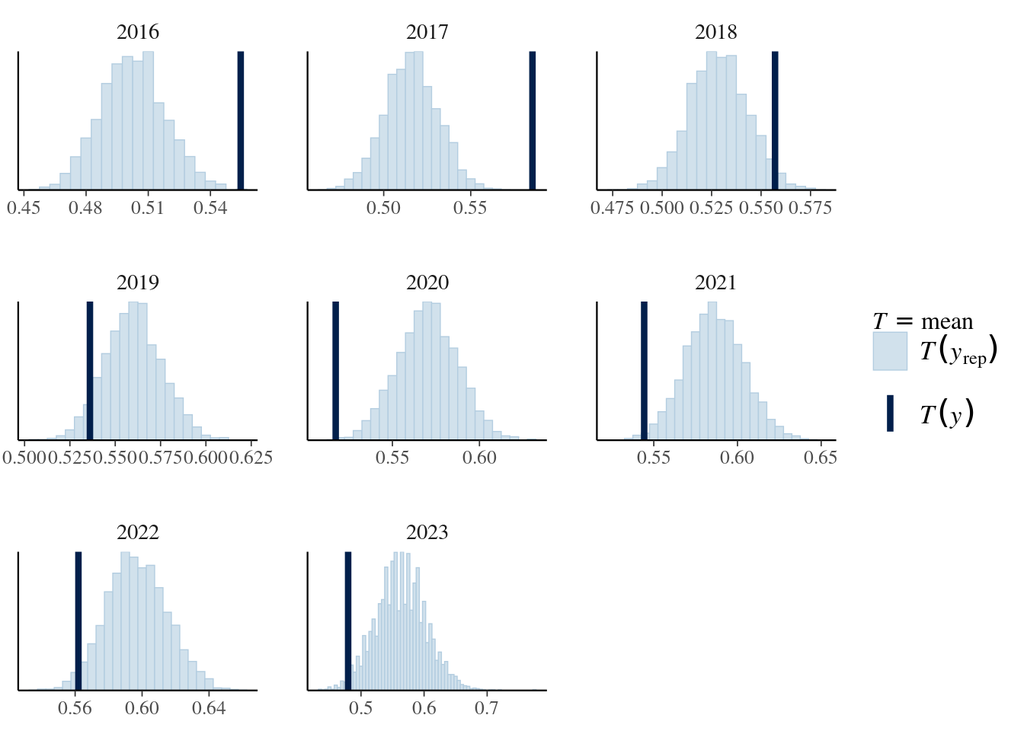

```r
annee <- d$annee_visite

ppc_stat_grouped(
  y = mod_nb$y,
  yrep = yrep,
  group = annee,
  stat = "mean",
  binwidth = .005
)
```

Etonnamment, le modèle exhibe une tendance croissante d’année en année, alors que les variations annuelles observées ne le sont pas.